# Simple regression

Bertrand-Mullainathan (AER, 2004)

Takuya Shimamura

2021-06-30

## 0. Preparation

- R and RStudio
  - *R* is a programming language and free software environment for statistical computing and graphics.  
    You can download R from [here for Windows users](https://cran.r-project.org/bin/windows/base/) and [here for Mac users](https://cran.r-project.org/bin/macosx/).
  - *RStudio* is an integrated development environment (IDE) for R. (Wikipedia).  
    To use RStudio, we need download R first. You can download Rstudio from [here](https://www.rstudio.com/products/rstudio/download/).
  - We can run R programs both in R and RStudio, but RSudio is recommended if you don’t have specific preferences.
- **Files in R**
  - `xxxx.Rproj` : Rproject file
  - `xxxx.Rmd` : Rmarkdown file (this)
  - `xxxx.R` : script file (simplest to use)
- **Directory**
  - Since we use *Rstudio*, we don’t have to set the working directory.  
    Thus, we can skip the code of `cd "Z: XXXXX"` in Stat.
- **Data source**
  - [Bertrand, Marianne, and Sendhil Mullainathan. 2004. “Are Emily and Greg More Employable Than Lakisha and Jamal? A Field Experiment on Labor Market Discrimination.” American Economic Review, 94 (4): 991-1013.](https://www.aeaweb.org/articles?id=10.1257/0002828042002561&ArticleSearch%5Bwithin%5D%5Bauthorlast%5D=1&ArticleSearch%5Bq%5D=Bertrand&JelClass%5Bvalue%5D=0&journal=1&from=j)
  - Data is avaralbe from [here](https://www.openicpsr.org/openicpsr/project/116023/version/V1/view).
- **folder structure in RStudio**  
  |——00_Input ## folder for original data  
  |——`lakisha_aer.dta` (get from [here](https://www.openicpsr.org/openicpsr/project/116023/version/V1/view))  
  |——00_Object ## folder for intermediate objects  
  |——xxxxx.rds  
  |——00_Output ## folder for output files  
  |——xxxxx.csv  
  |——000Rpro_rrrrr.Rproj ## `Rproject` file  
  |——01_simple_regression.Rmd <- this file  
  |——02_xxxxx.Rmd  
  |——03_xxxxx.Rmd  
  |——…..

### 0.1. Library

**Installing packages**  
We need to install packages first in R, using `install.packages()`.  
Once you install packages, we don’t have to run the following codes since the packages are saved in our local PC files.

```r
install.packages("tidyverse")
install.packages("stargazer")
install.packages("foreign")
install.packages("readstata13")
```

**Reading packages**  
We always need to read the required packages whenever we restart R program, using `library()`.

```r
library(tidyverse)    # data manipulation
library(stargazer)    # summarize data
library(foreign)      # read '.dta' file (Stata ver.15~)
library(readstata13)  # read '.dta' file (Stat old ver.)
```

### 0.2. Read data

```r
#--- read data ---#
df <- read.dta("./00_Input/lakisha_aer.dta")
```

## 1. Data manipulation

For more detail, I open some cheatsheets as follows;  
* [cheatsheet for data manipulation](https://raz316.github.io/cheatsheet_data_manipulation/) (GitHub)  
* [cheatsheet for figure and table](https://raz316.github.io/cheatsheet_fig_tbl/#talbe) (GitHub)

If you want to learn fundamental skills for R systematically,  
one of the best textbook is [R for Data Science](https://r4ds.had.co.nz/), available online for free.  
If you want to obtain the Japaneses ver., you can buy it from [Amazon](https://www.amazon.co.jp/-/en/Hadley-Wickham/dp/487311814X/ref=sr_1_2?crid=1TF526R8ZEGHX&dchild=1&keywords=r+for+data+science&qid=1619996458&sprefix=r+for+data%2Caps%2C265&sr=8-2) or [Rakuten](https://search.rakuten.co.jp/search/mall/r%E3%81%A7%E3%81%AF%E3%81%98%E3%82%81%E3%82%8B%E3%83%87%E3%83%BC%E3%82%BF%E3%82%B5%E3%82%A4%E3%82%A8%E3%83%B3%E3%82%B9/).

### 1.1. Data check

- *df* : dataframe in R

**data description**

| function | Stat | R |  |
| --- | --- | --- | --- |
| data structure | `describe` | `str()` |  |
| data view | `list` | *df*, `head()`, `view` |  |
| getting descriptive statistics | `summarize` | `summary`, `stargazer::stargazer()` |  |
| tables | `tabulate`, `table` | original function |  |

### 1.2. Data manipulation

- *fnc* : functions in both R and Stat
- *v1, v2, v3* : variables in the dataframe
- *x* : specific condition

**selection**

```
#--- Stata ver. ---#
fnc v1 v2 v3

#--- R ver. ---#
df %>%
  dplyr::select(v1, v2, v3) %>%
  fnc()
```

**conditioning**

```
#--- Stata ver. ---#
fnc if v1 == "x"

#--- R ver. ---#
df %>%
  filter(v1 == "x")
  fnc()
```

**sorting**

```
#--- Stata ver. ---#
sort v1

#--- R ver. ---#
df %>% arrange(v1)
```

**getting first *x* rows**

```
#--- Stata ver. ---#
list in 1/x

#--- R ver. ---#
df %>% head(n = x)
```

**rename variable names**

```
#--- Stata ver. ---#
rename old_name new_name

#--- R ver. ---#
df %>% raname(old_name = new_name)
```

### 1.3. Example

#### **Explain data structure**

We use `str()` to get explanation about the dataframe in R, instead of `describe` in Stat.  
`dplyr::select()` allows us to select the target variables.

```
#--- Stata ver. ---#
describe education yearsexp sex
```

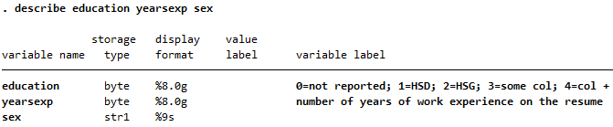

```r
#--- R ver. ---#
df %>%
  dplyr::select(education, yearsexp, sex) %>%
  str()
```

```
## 'data.frame':    4870 obs. of  3 variables:
##  $ education: int  4 3 4 3 3 4 4 3 4 4 ...
##  $ yearsexp : int  6 6 6 6 22 6 5 21 3 6 ...
##  $ sex      : chr  "f" "f" "f" "f" ...
```

#### **Show first 7 rows**

We use `head()` to show the limited rows of the dataframe in R, instead of `list` in Stat.  
`n = x` means that we can specify how many rows we want to show.

```
#--- Stata ver. ---#
list education-honors in 1/7
```

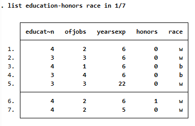

```r
#--- R ver. ---#
df %>%
  dplyr::select(education:honors, race) %>%  ## select `education` to `honors`
  head(n = 7)
```

```
##   education ofjobs yearsexp honors race
## 1         4      2        6      0    w
## 2         3      3        6      0    w
## 3         4      1        6      0    b
## 4         3      4        6      0    b
## 5         3      3       22      0    w
## 6         4      2        6      1    w
## 7         4      2        5      0    w
```

#### **Show first 7 *black* people**

We use `head()` to show the limited rows of the dataframe in R, instead of `list` in Stat.  
For the conditioning, we use `filter(v1 == x)` in R, instead of `if v1 == x` in Stat.

```
#--- Stata ver. ---#
list education yearsexp race in 1/7 if race == "b"
```

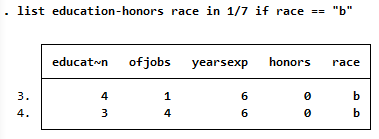

```r
#--- R ver. ---#
df %>%
  filter(race == "b") %>%
  dplyr::select(education:honors, race) %>%  ## select `education` to `honors`
  head(n = 7)
```

```
##    education ofjobs yearsexp honors race
## 3          4      1        6      0    b
## 4          3      4        6      0    b
## 8          3      4       21      0    b
## 9          4      3        3      0    b
## 10         4      2        6      0    b
## 11         4      4        8      0    b
## 13         4      4        4      0    b
```

#### **Get descriptive statistics**

```
#--- Stata ver. ---#
summarize education yearsexp sex
```

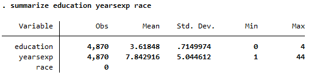

```r
#--- R ver. ---#
df %>%
  dplyr::select(education, yearsexp, sex) %>%
  summary()
```

```
##    education        yearsexp          sex
##  Min.   :0.000   Min.   : 1.000   Length:4870
##  1st Qu.:3.000   1st Qu.: 5.000   Class :character
##  Median :4.000   Median : 6.000   Mode  :character
##  Mean   :3.618   Mean   : 7.843
##  3rd Qu.:4.000   3rd Qu.: 9.000
##  Max.   :4.000   Max.   :44.000
```

Since `sex` is string, it is dropped from the table.

#### **Get descriptive statistics of specific candidates**

| condition | Stat | R |
| --- | --- | --- |
| *AND* | `&` | `&`, `,` |
| *OR* | `\|` | `\|` |

```
#--- Stata ver. ---#

** AND
sum education yearsexp if education == 4 & yearsexp > 20

** OR
sum education yearsexp if education == 4 | yearsexp > 20
```

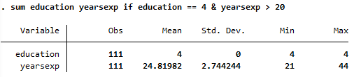

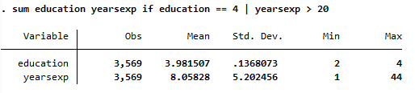

```r
#--- R ver. ---#

## AND using `&`
df %>%
  dplyr::filter(education == 4 & yearsexp > 20) %>%
  dplyr::select(education, yearsexp, sex) %>%
  summary()

## AND using `,`
df %>%
  dplyr::filter(education == 4, yearsexp > 20) %>%
  dplyr::select(education, yearsexp, sex) %>%
  summary()

## OR using `|`
df %>%
  dplyr::filter(education == 4 | yearsexp > 20) %>%
  dplyr::select(education, yearsexp, sex) %>%
  summary()
```

```
##    education    yearsexp         sex
##  Min.   :4   Min.   :21.00   Length:111
##  1st Qu.:4   1st Qu.:23.00   Class :character
##  Median :4   Median :26.00   Mode  :character
##  Mean   :4   Mean   :24.82
##  3rd Qu.:4   3rd Qu.:26.00
##  Max.   :4   Max.   :44.00
```

```
##    education    yearsexp         sex
##  Min.   :4   Min.   :21.00   Length:111
##  1st Qu.:4   1st Qu.:23.00   Class :character
##  Median :4   Median :26.00   Mode  :character
##  Mean   :4   Mean   :24.82
##  3rd Qu.:4   3rd Qu.:26.00
##  Max.   :4   Max.   :44.00
```

```
##    education        yearsexp          sex
##  Min.   :2.000   Min.   : 1.000   Length:3569
##  1st Qu.:4.000   1st Qu.: 5.000   Class :character
##  Median :4.000   Median : 7.000   Mode  :character
##  Mean   :3.982   Mean   : 8.058
##  3rd Qu.:4.000   3rd Qu.: 9.000
##  Max.   :4.000   Max.   :44.000
```

## 2. Table

### 2.1. Stat’s function `table`

Obviously, Stat is much easier than R.  
* There might be an effective function for this in R, but I couldn’t find.

#### **Create table according to `race`**

```
#--- Stata ver. ---#
** show the total number of candidates according to race
table race, contents(N education N yearsexp)

** show ave. and st.dev. according to race
table race, contents(mean education mean yearsexp sd education sd yearsexp)

** show calculate quantile according to race
table race, c(p25 yearsexp p50 yearsexp p75 yearsexp )
```

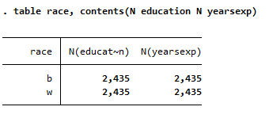

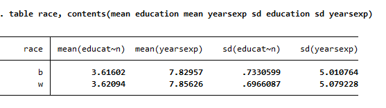

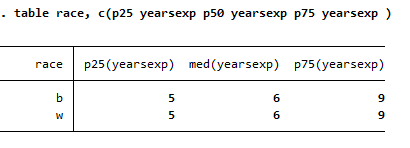

```r
#--- R ver. ---#

## show the total number of candidates according to race
df %>%
  group_by(race) %>%
  summarise(N = n()) %>%
  as.data.frame()

## show ave. and st.dev. according to race
df %>% as.tibble() %>%
  group_by(race) %>%
  summarise_at(c("education", "yearsexp"), .funs = c(mean, sd), na.rm = TRUE) %>%
  as.data.frame()

## show calculate quantile according to race
df %>%
  group_by(race) %>%
  summarise_at("yearsexp", .funs = quantile, na.rm = TRUE) %>%
  mutate(position = c("min", "p25", "med", "p75", "max")) %>%
  pivot_wider(names_from = position, values_from = yearsexp) %>%
  as.data.frame()
```

```
##   race    N
## 1    b 2435
## 2    w 2435
```

```
##   race education_fn1 yearsexp_fn1 education_fn2 yearsexp_fn2
## 1    b      3.616016     7.829569     0.7330600     5.010764
## 2    w      3.620945     7.856263     0.6966087     5.079228
```

```
##   race min p25 med p75 max
## 1    b   1   5   6   9  44
## 2    w   1   5   6   9  26
```

### 2.2. Stat’s function `tabulate`

Obviously, Stat is much easier than R.  
* There might be an effective function for this in R, but I couldn’t find.

#### **Tabulate one variable**

We need to create our own function in R to run the same function as `tabulate` in Stat.  
* There might be an effective function for this in R, but I couldn’t find.

```
#--- Stata ver. ---#
tabulate yearsexp
```

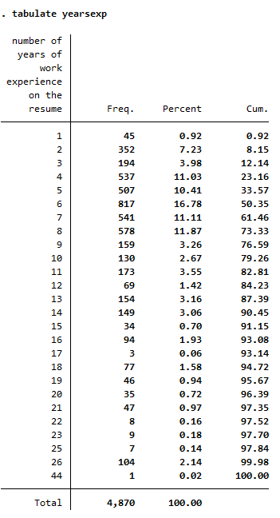

```r
#--- R ver. ---#

df %>%
  #-- create group according to `yearsexp` --#
  group_by(yearsexp) %>%

  #-- count candidates according to `yearsexp` --#
  summarise(Freq. = n()) %>%
  as.data.frame() %>%

  #-- make `Percent` and `Cum.` --#
  mutate(
    # make a row of the total number of candidates
    Total = sum(Freq.),
    # calculate the ratio according to `yearsexp`; and manipulate the significant figures
    Percent = (Freq. / Total * 100) %>% sprintf("%1.3f", .) %>% as.numeric(),
    # calculate the cumulation; and manipulate the significant figures
    Cum. = cumsum(Percent) %>% sprintf("%1.2f", .) %>% as.numeric()
  ) %>% as.data.frame() %>%

  #-- drop the column `Total` --#
  dplyr::select(-Total)
```

```
##    yearsexp Freq. Percent   Cum.
## 1         1    45   0.924   0.92
## 2         2   352   7.228   8.15
## 3         3   194   3.984  12.14
## 4         4   537  11.027  23.16
## 5         5   507  10.411  33.57
## 6         6   817  16.776  50.35
## 7         7   541  11.109  61.46
## 8         8   578  11.869  73.33
## 9         9   159   3.265  76.59
## 10       10   130   2.669  79.26
## 11       11   173   3.552  82.81
## 12       12    69   1.417  84.23
## 13       13   154   3.162  87.39
## 14       14   149   3.060  90.45
## 15       15    34   0.698  91.15
## 16       16    94   1.930  93.08
## 17       17     3   0.062  93.14
## 18       18    77   1.581  94.72
## 19       19    46   0.945  95.67
## 20       20    35   0.719  96.39
## 21       21    47   0.965  97.35
## 22       22     8   0.164  97.52
## 23       23     9   0.185  97.70
## 24       25     7   0.144  97.85
## 25       26   104   2.136  99.98
## 26       44     1   0.021 100.00
```

#### **Tabulate two variables**

We need to create our own function in R to run the same function as `tabulate` in Stat.  
* There might be an effective function for this in R, but I couldn’t find.

```
#--- Stata ver. ---#
tabulate yearsexp race
```

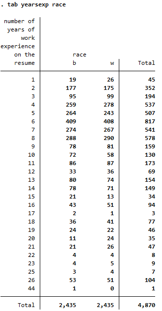

```r
#--- R ver. ---#

df %>%

  #-- create group according to `yearsexp` --#
  group_by(yearsexp, race) %>%

  #-- count candidates according to `yearsexp` --#
  summarise(Freq. = n()) %>%

  #-- pivot dataframe based on `race` --#
  pivot_wider(names_from = race, values_from = Freq.) %>%

  #-- make `Total` --#
  mutate(Total = b + w) %>%

  #-- convert the dataframe type from `tibble` to `data.frame` --#
  as.data.frame()
```

```
##    yearsexp   b   w Total
## 1         1  19  26    45
## 2         2 177 175   352
## 3         3  95  99   194
## 4         4 259 278   537
## 5         5 264 243   507
## 6         6 409 408   817
## 7         7 274 267   541
## 8         8 288 290   578
## 9         9  78  81   159
## 10       10  72  58   130
## 11       11  86  87   173
## 12       12  33  36    69
## 13       13  80  74   154
## 14       14  78  71   149
## 15       15  21  13    34
## 16       16  43  51    94
## 17       17   2   1     3
## 18       18  36  41    77
## 19       19  24  22    46
## 20       20  11  24    35
## 21       21  21  26    47
## 22       22   4   4     8
## 23       23   4   5     9
## 24       25   3   4     7
## 25       26  53  51   104
## 26       44   1  NA    NA
```

### 2.3. R’s package `stargazer`

The package `stargazer` is a powerful tool to draw tables in R.  
The usage of `stargazer::stargazer()` is similar to that of the function `base::summary()`.  
`stargazer()` has options for `type`, such as `latex`(default), `html`, `text`.  
For more details, this is [the best cheatsheet for `stargazer`](https://www.jakeruss.com/cheatsheets/stargazer/) by Jakerussr.

#### **Get descriptive statistics**

```r
#--- R ver. ---#

## LaTex
df %>%
  dplyr::filter(education == 4 & yearsexp > 20) %>%
  dplyr::select(education, yearsexp, sex) %>%
  stargazer(type = "latex")

## HTML for viewing in browser
df %>%
  dplyr::filter(education == 4 & yearsexp > 20) %>%
  dplyr::select(education, yearsexp, sex) %>%
  stargazer(type = "html")

## text for viewing in RStudio or text file
df %>%
  dplyr::filter(education == 4 & yearsexp > 20) %>%
  dplyr::select(education, yearsexp, sex) %>%
  stargazer(type = "text")
```

```
##
## % Table created by stargazer v.5.2.2 by Marek Hlavac, Harvard University. E-mail: hlavac at fas.harvard.edu
## % Date and time: 水, 6 30, 2021 - 10:27:15
## \begin{table}[!htbp] \centering
##   \caption{}
##   \label{}
## \begin{tabular}{@{\extracolsep{5pt}}lccccccc}
## \\[-1.8ex]\hline
## \hline \\[-1.8ex]
## Statistic & \multicolumn{1}{c}{N} & \multicolumn{1}{c}{Mean} & \multicolumn{1}{c}{St. Dev.} & \multicolumn{1}{c}{Min} & \multicolumn{1}{c}{Pctl(25)} & \multicolumn{1}{c}{Pctl(75)} & \multicolumn{1}{c}{Max} \\
## \hline \\[-1.8ex]
## education & 111 & 4.000 & 0.000 & 4 & 4 & 4 & 4 \\
## yearsexp & 111 & 24.820 & 2.744 & 21 & 23 & 26 & 44 \\
## \hline \\[-1.8ex]
## \end{tabular}
## \end{table}
```

```
##
## <table style="text-align:center"><tr><td colspan="8" style="border-bottom: 1px solid black"></td></tr><tr><td style="text-align:left">Statistic</td><td>N</td><td>Mean</td><td>St. Dev.</td><td>Min</td><td>Pctl(25)</td><td>Pctl(75)</td><td>Max</td></tr>
## <tr><td colspan="8" style="border-bottom: 1px solid black"></td></tr><tr><td style="text-align:left">education</td><td>111</td><td>4.000</td><td>0.000</td><td>4</td><td>4</td><td>4</td><td>4</td></tr>
## <tr><td style="text-align:left">yearsexp</td><td>111</td><td>24.820</td><td>2.744</td><td>21</td><td>23</td><td>26</td><td>44</td></tr>
## <tr><td colspan="8" style="border-bottom: 1px solid black"></td></tr></table>
```

```
##
## =======================================================
## Statistic  N   Mean  St. Dev. Min Pctl(25) Pctl(75) Max
## -------------------------------------------------------
## education 111 4.000   0.000    4     4        4      4
## yearsexp  111 24.820  2.744   21     23       26    44
## -------------------------------------------------------
```

### 2.4. Saving table

To save the tables generated by `stargazer()`, we use `cat::capture.output()`.

```
#--- Stata ver. ---#

** install the package `outreg2`
ssc install outreg2

** save to MS Excel
outreg2 using race_1, replace sum(log) excel

** save to MS Word
outreg2 using race_1, replace sum(log) word
```

```r
#--- R ver. ---#

## save to HTML
capture.output(
  df %>%
    dplyr::filter(education == 4 & yearsexp > 20) %>%
    dplyr::select(education, yearsexp, sex) %>%
    stargazer(type = "html"),
  file = "./00_Output/stat_dev.html",  ## designate the file name (html file)
  append = FALSE  ## `FALSE`: create a new file, `TRUE`: append to the existing file
)

## save to text
capture.output(
  df %>%
    dplyr::filter(education == 4 & yearsexp > 20) %>%
    dplyr::select(education, yearsexp, sex) %>%
    stargazer(type = "text"),
  file = "./00_Output/stat_dev.txt",  ## designate the file name (text file)
  append = FALSE  ## `FALSE`: create a new file, `TRUE`: append to the existing file
)
```

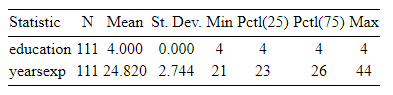

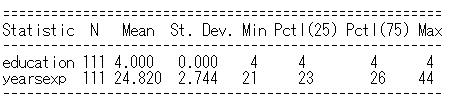

## 3. Figure

- The package `ggplot2` allows us to visualize beautiful figures in R though it is a little hard to master.
- The package `tidyverse` which we have installed at first contains `ggplot2`;  
  thus we don’t have to read the package like `library(ggplot2)`.

### 3.1. Histgram

We use the functions of `ggplot` and `geom_histgram` in the package `ggplot2`, instead of `hist` in Stat.

#### **Visualize histogram for two variables**

We visualize histogram (density) of *yearsexp* according to *race*.

```
#--- Stata ver. ---#
hist yearsexp, by(race)
```

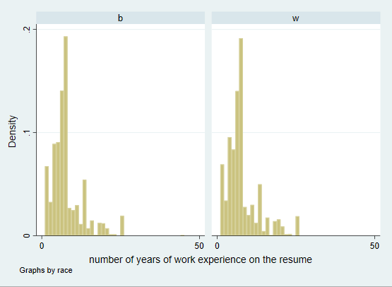

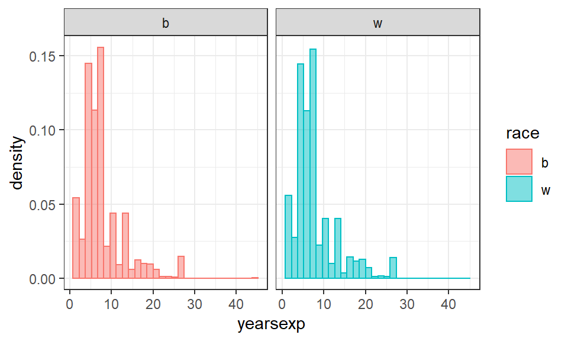

```r
ggplot(data = df, aes(x = yearsexp, col = race, fill = race)) +  ## identify data and variables
  geom_histogram(aes(y = ..density..), alpha = 0.5) +  ## identify density or frequency (default is freq.)
  facet_grid(.~ race) +  ## create grids
  theme_bw()  ## select theme
```

#### **Combine multiple graphs**

We use `ggpubr::ggarrange()` to combine multiple `ggplot` objects.  
If you haven’t install the package `ggpubr`, run the following code `install.packages("ggpubr")`

```
#--- Stata ver. ---#
hist yearsexp if race == "b", name(b)
hist yearsexp if race == "w", name(w)
graph combine b w
```

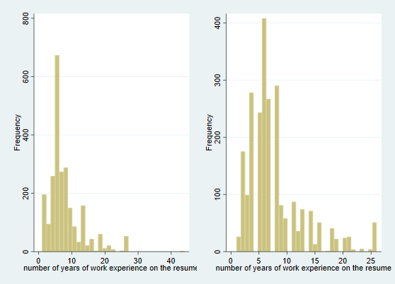

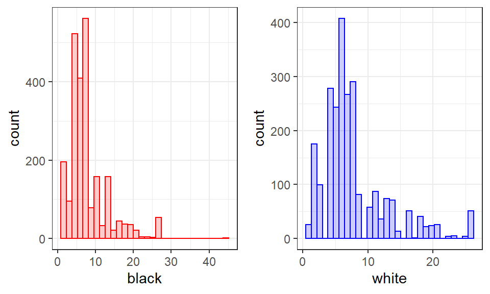

```r
gg_black <- df %>%
  filter(race == "b") %>%
  ggplot(aes(x = yearsexp)) +  ## identify variables
  geom_histogram(col = "red", fill = "red", alpha = 0.2) +  ## specify color
  theme_bw() +  ## select theme
  xlab("black")  ## change x-axis title

gg_white <- df %>%
  filter(race == "w") %>%
  ggplot(aes(x = yearsexp)) +  ## identify variables
  geom_histogram(col = "blue", fill = "blue", alpha = 0.2) +  ## specify color
  theme_bw() +  ## select theme
  xlab("white")  ## change x-axis title

ggpubr::ggarrange(gg_black, gg_white)
```

#### **Overlap multiple variables**

We can choose several types of overlapping by specifying `position =`.  
`position` has several parameters, such as `identity`(default), `dodge`, and `stack`.

```
#--- Stata ver. ---#
twoway (hist yearsexp if race == "b", freq disc color(green)) /*
　　　  　*/(hist yearsexp if race == "w", freq disc fcolor(none) lcolor(black)) /*
     */ ,legend(order(1 " Black" 2 "White" ))
```

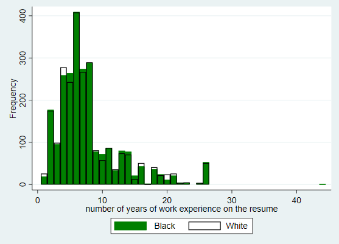

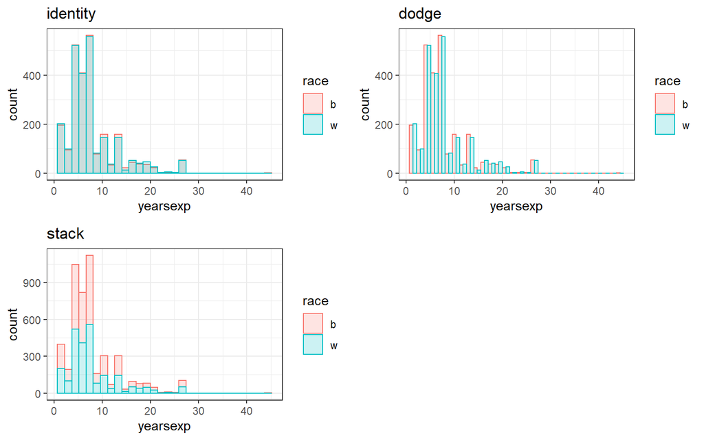

```r
## position = "identity"
gg_identity <- ggplot(data = df) +
  geom_histogram(position = "identity", aes(x = yearsexp, col = race, fill = race), alpha = 0.2) +
  theme_bw() +
  ggtitle("identity")  ## insert a figure title

## position = "dodge"
gg_dodge <- ggplot(data = df) +
  geom_histogram(position = "dodge", aes(x = yearsexp, col = race, fill = race), alpha = 0.2) +
  theme_bw() +
  ggtitle("dodge")  ## insert a figure title

## position = "stack"
gg_stack <- ggplot(data = df) +
  geom_histogram(position = "stack", aes(x = yearsexp, col = race, fill = race), alpha = 0.2) +
  theme_bw() +
  ggtitle("stack")  ## insert a figure title

ggpubr::ggarrange(gg_identity, gg_dodge, gg_stack)
```

`geom_density()` draws a probability density function.

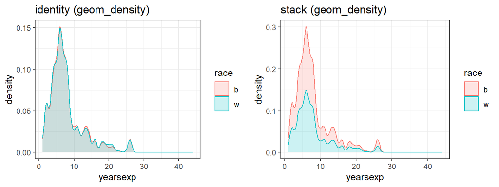

```r
gg_identity_density <- ggplot(data = df) +
  geom_density(position = "identity", aes(x = yearsexp, col = race, fill = race), alpha = 0.2) +
  theme_bw() +
  ggtitle("identity (geom_density)")  ## insert a figure title

gg_stack_density <- ggplot(data = df) +
  geom_density(position = "stack", aes(x = yearsexp, col = race, fill = race), alpha = 0.2) +
  theme_bw() +
  ggtitle("stack (geom_density)")  ## insert a figure title

ggpubr::ggarrange(gg_identity_density, gg_stack_density)
```

## 4. T-test

We use `t.test()` for the t-test in R, instead of `ttest` in Stat.

Before starting t-test, we need to convert *string* variables to *numeric* variables.

| variable | data type | example | conversion |
| --- | --- | --- | --- |
| `yearsexp` | numeric | 3, 7, 12 | non-necessary |
| `education` | numeric (category) | 1–4 | non-necessary |
| `call` | numeric (dummy) | 0 or 1 | non-necessary |
| `race` | string | “b” or “w” | necessary |

In this case, we convert each element of `race` as follows: `"b"` to `1` and `"w"` to `0`.

```
#--- Stata ver. ---#
gen race_dum = 1 if race == "b"
replace race_dum = 0 if race == "w"

*** labeling of `race_dum`
label variable race_dum "1 if black, 0 if white"
```

```r
#--- R ver. ---#
df <- df %>%
  mutate(race_dum = case_when(race == "b" ~ 1, race == "w" ~ 0))

## If there are some elements neither "b" nor "w", the element will be converted as "NA".
df %>% group_by(race_dum) %>% summarise(n = n())  ## check whether there are "NA"s
```

```
## # A tibble: 2 x 2
##   race_dum     n
##      <dbl> <int>
## 1        0  2435
## 2        1  2435
```

### 4.1. T-test for average

We test whether the mean value of variable `call` is equal to `0.5` or not.

```
#--- Stata ver. ---#

** `call`: use the original variable
ttest call == 0.5

** `race`: use the converted variable
ttest race_dum == 0.5
```

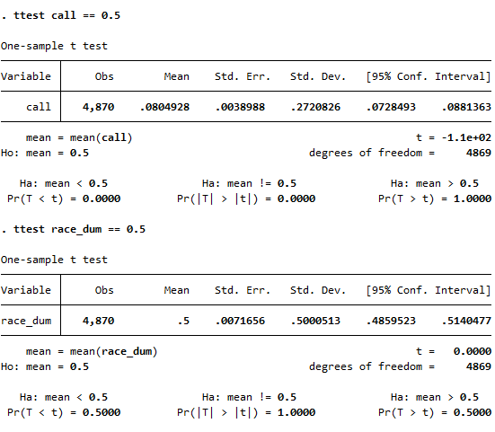

```r
#--- R ver. ---#

## `call`: use the original variable
t.test(
  df$call,
  alternative = "two.sided",  ## select from "two.sided"(default), "less", "greater"
  mu = 0.5,  ## H0: equal to x, H1: not equal to x (default is 0)
  conf.level = 0.95  ## 95 % of confident level (default is 0.95)
)

## `race`: use the converted variable (abbrev.)
t.test(df$race_dum, mu = 0.5)
```

```
##
##  One Sample t-test
##
## data:  df$call
## t = -107.6, df = 4869, p-value < 2.2e-16
## alternative hypothesis: true mean is not equal to 0.5
## 95 percent confidence interval:
##  0.07284931 0.08813631
## sample estimates:
##  mean of x
## 0.08049281
##
##
##  One Sample t-test
##
## data:  df$race_dum
## t = 0, df = 4869, p-value = 1
## alternative hypothesis: true mean is not equal to 0.5
## 95 percent confidence interval:
##  0.4859523 0.5140477
## sample estimates:
## mean of x
##       0.5
```

### 4.2. T-test for the difference of averages

We test whether the mean values of `call` are equal between `race` or not.  
In this case, we can use both `race` (string) and `race_dum` (numeric).

There are two types of t-test according to the two variances are equal or not:

| type | two variances | Stat’s option | R’s option |
| --- | --- | --- | --- |
| t-test (normal) | equal | *none* (default) | `var.equal = TRUE` |
| Welch’s t-test | unequal | `unequal`, `w`, `unequal w` | `var.equal = FALSE` (default) |

```
#--- Stata ver. ---#
** t-test (normal)
ttest call, by(race)

** Welch's t-test
ttest call, by(race) w
```

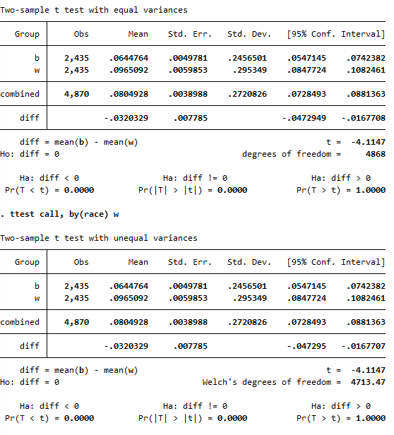

```r
#--- R ver. ---#
## t-test for education
t.test(call ~ race, data = df, var.equal = TRUE)

## t-test for education
t.test(call ~ race, data = df)
```

```
##
##  Two Sample t-test
##
## data:  call by race
## t = -4.1147, df = 4868, p-value = 3.941e-05
## alternative hypothesis: true difference in means is not equal to 0
## 95 percent confidence interval:
##  -0.04729491 -0.01677080
## sample estimates:
## mean in group b mean in group w
##      0.06447639      0.09650924
##
##
##  Welch Two Sample t-test
##
## data:  call by race
## t = -4.1147, df = 4711.6, p-value = 3.943e-05
## alternative hypothesis: true difference in means is not equal to 0
## 95 percent confidence interval:
##  -0.04729503 -0.01677067
## sample estimates:
## mean in group b mean in group w
##      0.06447639      0.09650924
```

### 4.3. Compare t-test and single regression

We compare the results of t-test and single regression. (see section 5 and 6 for the detail of single regression)

```r
reg <- lm(call ~ race_dum, data = df)
summary(reg)
```

```
##
## Call:
## lm(formula = call ~ race_dum, data = df)
##
## Residuals:
##      Min       1Q   Median       3Q      Max
## -0.09651 -0.09651 -0.06448 -0.06448  0.93552
##
## Coefficients:
##              Estimate Std. Error t value Pr(>|t|)
## (Intercept)  0.096509   0.005505  17.532  < 2e-16 ***
## race_dum    -0.032033   0.007785  -4.115 3.94e-05 ***
## ---
## Signif. codes:  0 '***' 0.001 '**' 0.01 '*' 0.05 '.' 0.1 ' ' 1
##
## Residual standard error: 0.2716 on 4868 degrees of freedom
## Multiple R-squared:  0.003466,   Adjusted R-squared:  0.003261
## F-statistic: 16.93 on 1 and 4868 DF,  p-value: 3.941e-05
```

#### **The equivalence**

The table below compares the results of normal t-test and simple regression. We can see that both are same essentially.

|  | coefficient | st. dev. | t-value | significance |
| --- | --- | --- | --- | --- |
| t-test | -0.0320$^{(1)}$ | 0.0078 | -4.1147 | *** |
| regression | -0.0320 | 0.0078 | -4.1147 | *** |

$^{(1)}$ mean value of the lower and upper 95% of significant intervals

#### **The difference**

Unlike t-test, regression can show $R^2$ (0.0035) and $adj. R^2$ (0.0033).  
Although both values are small, it does not reject the significance of call back difference between races.  
In other ward, the grade of $R^2$ has nothing to do with causality analysis.

## 5. Single regression

We regress income (`linc`) on work experience (`yearsexp`).

### 5.1. Scatter plot

The largest value of `yearsexp` is `44` candidated by a black woman with category 4 of education.  
However, her `linc` is unknown; thus, there is a space between `26` (the second largest) to `44` of the x-axis (`yearsexp`).

```
#--- Stata ver. ---#
** good
scatter linc yearsexp

** better to see
*** calculate `linc` according to `yearsexp`
bysort yearsexp: egen linc_yrexp = mean(linc)
*** plot
scatter linc_yrexp yearsexp
```

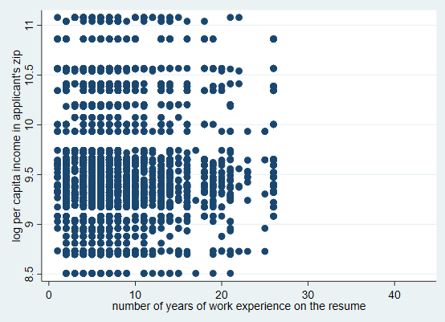

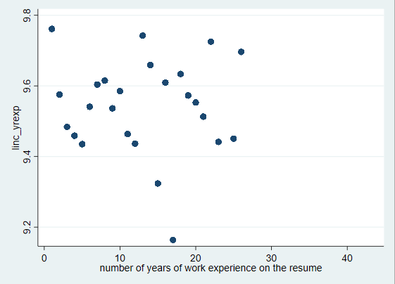

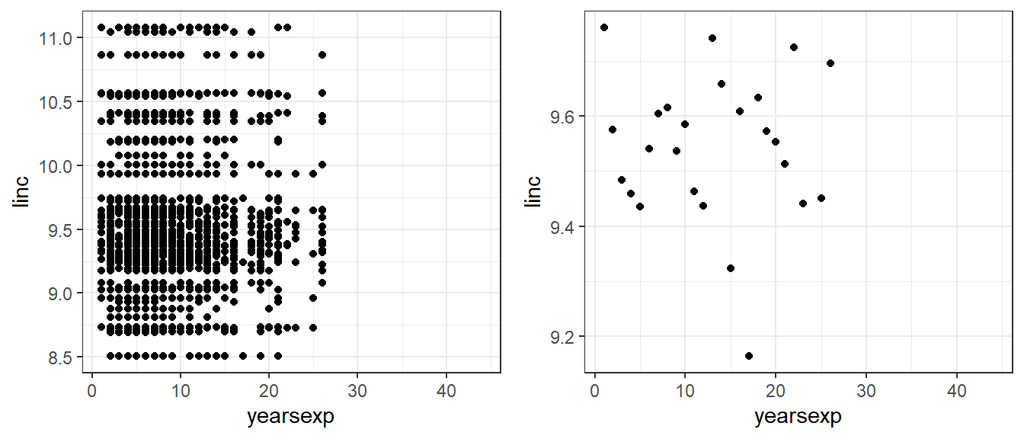

```r
#--- R ver. ---#

## good
gg1 <- df %>%
  ggplot() +
  geom_point(aes(x = yearsexp, y = linc)) +
  theme_bw()

## better to see
gg2 <- df %>%
  ## summarize average of `linc` according to `yearsexp`
  group_by(yearsexp) %>%
  summarise_at("linc", mean, na.rm = TRUE) %>%
  ## plot
  ggplot() +
  geom_point(aes(x = yearsexp, y = linc)) +
  theme_bw()

ggpubr::ggarrange(gg1, gg2)
```

### 5.2. Regression

We use `lm()` for linear regression in R, instead of `reg` in Stat.  
If you haven’t install the package `sandwich`, run the following code `install.packages("sandwich")`

```
#--- Stata ver. ---#

** normal sd. error
regress linc yearsexp

** heteroskedasticity robust sd. error
regress linc yearsexp, robust
```

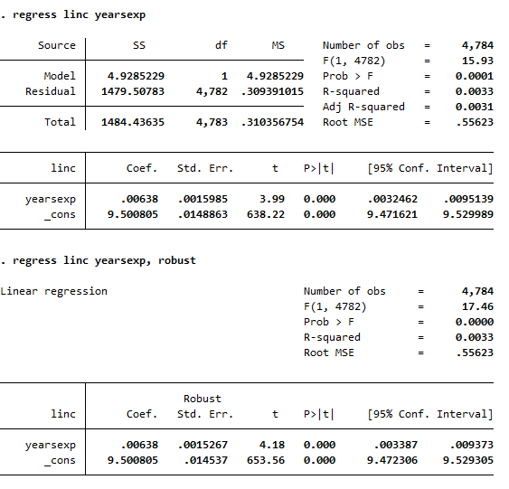

```r
library(sandwich)

## normal sd. error
reg <- lm(linc ~ yearsexp, data = df)
stargazer(reg, type = "text")

## heteroskedasticity robust sd. error
robust_se <- vcovHC(reg, type = "HC1") %>%  ## heteroskedasticity robust variance-covariance matrix
  diag() %>% sqrt()  ## diag(): extract covariance,  sqrt(): covariance -> sd. error
stargazer(reg, type = "text",
          se = list(robust_se))
```

```
##
## ===============================================
##                         Dependent variable:
##                     ---------------------------
##                                linc
## -----------------------------------------------
## yearsexp                     0.006***
##                               (0.002)
##
## Constant                     9.501***
##                               (0.015)
##
## -----------------------------------------------
## Observations                   4,784
## R2                             0.003
## Adjusted R2                    0.003
## Residual Std. Error      0.556 (df = 4782)
## F Statistic          15.930*** (df = 1; 4782)
## ===============================================
## Note:               *p<0.1; **p<0.05; ***p<0.01
##
## ===============================================
##                         Dependent variable:
##                     ---------------------------
##                                linc
## -----------------------------------------------
## yearsexp                     0.006***
##                               (0.002)
##
## Constant                     9.501***
##                               (0.015)
##
## -----------------------------------------------
## Observations                   4,784
## R2                             0.003
## Adjusted R2                    0.003
## Residual Std. Error      0.556 (df = 4782)
## F Statistic          15.930*** (df = 1; 4782)
## ===============================================
## Note:               *p<0.1; **p<0.05; ***p<0.01
```

**Compare two table**

```r
stargazer(reg, reg, type = "text",
          se = list(NULL, robust_se),
          column.labels = c("normal", "robust"))
```

```
##
## ============================================================
##                                     Dependent variable:
##                                 ----------------------------
##                                             linc
##                                     normal        robust
##                                      (1)            (2)
## ------------------------------------------------------------
## yearsexp                           0.006***      0.006***
##                                    (0.002)        (0.002)
##
## Constant                           9.501***      9.501***
##                                    (0.015)        (0.015)
##
## ------------------------------------------------------------
## Observations                        4,784          4,784
## R2                                  0.003          0.003
## Adjusted R2                         0.003          0.003
## Residual Std. Error (df = 4782)     0.556          0.556
## F Statistic (df = 1; 4782)        15.930***      15.930***
## ============================================================
## Note:                            *p<0.1; **p<0.05; ***p<0.01
```

### 5.3. Prediction

```
#--- Stat ver ---#

** (1) prediction
predict yhat_1, xb

** (2) plot
twoway(scatter linc_yrexp yearsexp)(line yhat_1 yearsexp)
```

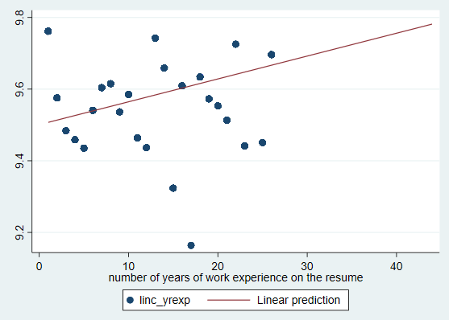

```
##        fit      lwr      upr
## 1 9.539085 9.522302 9.555869
## 2 9.539085 9.522302 9.555869
## 3 9.539085 9.522302 9.555869
## 4 9.539085 9.522302 9.555869
## 5 9.641166 9.594064 9.688268
## 6 9.539085 9.522302 9.555869
```

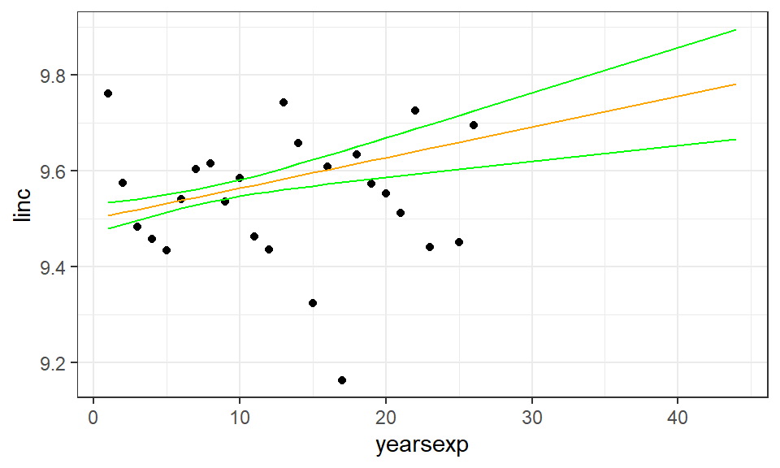

```r
#--- R ver. ---#

## (1) create a new dataframe which becomes x-axis.
df_new <- df %>% dplyr::select(yearsexp)

## (2) predict confidence interval at 95% significance level
conf_interval <- predict(reg, newdata = df_new, interval = "confidence", level = 0.95) %>%
  as.data.frame()  ## convert matrix to dataframe
head(conf_interval)

## (3) conbine two dataframes: original dataframe and predicted confident interval
df1 <- data.frame()  ## reset `df1`
df1 <- cbind(df, conf_interval)

## (4) plot
ggplot() +
  geom_point(data = df1 %>% group_by(yearsexp) %>% summarise_at("linc", mean, na.rm = TRUE),
    aes(x = yearsexp, y = linc)) +
  geom_line(data = df1, aes(x = yearsexp, y = fit), col = "orange") +  ## add line of fitted
  geom_line(data = df1, aes(x = yearsexp, y = lwr), col = "green") +  ## add curve of lower confident level
  geom_line(data = df1, aes(x = yearsexp, y = upr), col = "green") +  ## add curve of upper confident level
  theme_bw()
```

**Shortcut for plotting**

```
#--- Stata ver. ---#
twoway(scatter linc_yrexp yearsexp)(line yhat_1 yearsexp)(lfit linc yearsexp), /*
*/ legend(order(2 "predict" 3 "lfit"))
```

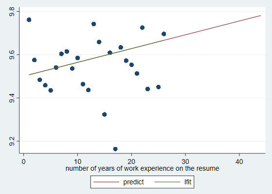

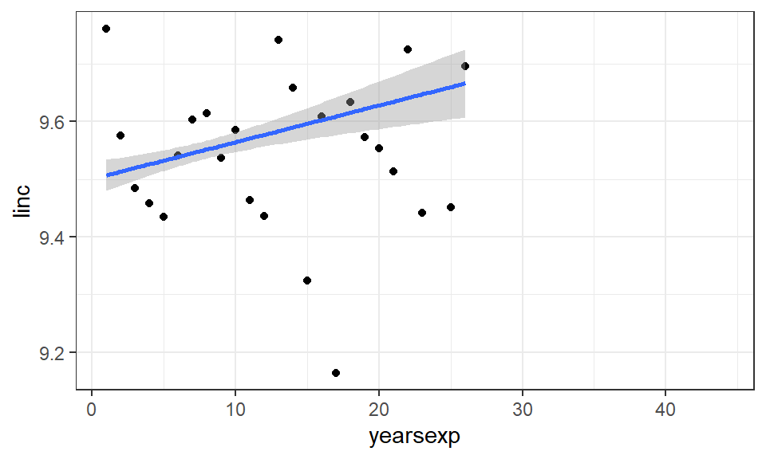

```r
#--- R ver. ---#
ggplot() +
  geom_point(data = df %>% group_by(yearsexp) %>% summarise_at("linc", mean, na.rm = TRUE),
             aes(x = yearsexp, y = linc)) +
  geom_smooth(data = df, aes(x = yearsexp, y = linc), method = "lm", level = 0.95) +
  theme_bw()
```

## 6. Linear probability model

We regress results of application (dummy variable `call`) on work experience (`yearsexp`).  
Although the explained variable is dummy variable, the codes are the same as linear regression above.

### 6.1. Scatter plot

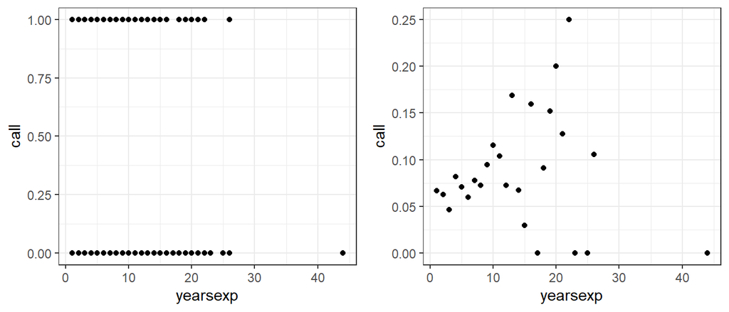

```r
#--- R ver. ---#

## good
gg1 <- df %>%
  ggplot() +
  geom_point(aes(x = yearsexp, y = call)) +
  theme_bw()

## better to see
gg2 <- df %>%
  ## summarize average of `call` according to `yearsexp`
  group_by(yearsexp) %>%
  summarise_at("call", mean, na.rm = TRUE) %>%
  ## plot
  ggplot() +
  geom_point(aes(x = yearsexp, y = call)) +
  theme_bw()

ggpubr::ggarrange(gg1, gg2)
```

### 6.2. Regression

```r
library(sandwich)

## normal sd. error
reg <- lm(call ~ yearsexp, data = df)
stargazer(reg, type = "text")

## heteroskedasticity robust sd. error
robust_se <- vcovHC(reg, type = "HC1") %>%  ## heteroskedasticity robust variance-covariance matrix
  diag() %>% sqrt()  ## diag(): extract covariance,  sqrt(): covariance -> sd. error
stargazer(reg, type = "text",
          se = list(robust_se))
```

```
##
## ===============================================
##                         Dependent variable:
##                     ---------------------------
##                                call
## -----------------------------------------------
## yearsexp                     0.003***
##                               (0.001)
##
## Constant                     0.055***
##                               (0.007)
##
## -----------------------------------------------
## Observations                   4,870
## R2                             0.004
## Adjusted R2                    0.004
## Residual Std. Error      0.272 (df = 4868)
## F Statistic          18.444*** (df = 1; 4868)
## ===============================================
## Note:               *p<0.1; **p<0.05; ***p<0.01
##
## ===============================================
##                         Dependent variable:
##                     ---------------------------
##                                call
## -----------------------------------------------
## yearsexp                     0.003***
##                               (0.001)
##
## Constant                     0.055***
##                               (0.007)
##
## -----------------------------------------------
## Observations                   4,870
## R2                             0.004
## Adjusted R2                    0.004
## Residual Std. Error      0.272 (df = 4868)
## F Statistic          18.444*** (df = 1; 4868)
## ===============================================
## Note:               *p<0.1; **p<0.05; ***p<0.01
```

**Compare two table**

```r
stargazer(reg, reg, type = "text",
          se = list(NULL, robust_se),
          column.labels = c("normal", "robust"))
```

```
##
## ============================================================
##                                     Dependent variable:
##                                 ----------------------------
##                                             call
##                                     normal        robust
##                                      (1)            (2)
## ------------------------------------------------------------
## yearsexp                           0.003***      0.003***
##                                    (0.001)        (0.001)
##
## Constant                           0.055***      0.055***
##                                    (0.007)        (0.007)
##
## ------------------------------------------------------------
## Observations                        4,870          4,870
## R2                                  0.004          0.004
## Adjusted R2                         0.004          0.004
## Residual Std. Error (df = 4868)     0.272          0.272
## F Statistic (df = 1; 4868)        18.444***      18.444***
## ============================================================
## Note:                            *p<0.1; **p<0.05; ***p<0.01
```